# MLE Lab 1: Intermediate R Programming

Mateo Villamizar-Chaparro (sv161@duke.edu)

Aug 21, 2020

## **Let’s begin with**:

1. Introductions
   - What’s your name?
   - Why are you taking this class?
   - What is the strangest thing you’ve done during the pandemic?
2. Expectations for the class
   - We are under weird times and circumstances where we are all learning how to deal with new things. So if you have any issues with the material or the class please let me know. Both Prof. Stegmüeller and I will try to be as helpful as possible.
   - During lab, *please* have your camera on at all times. It helps when you can see people’s faces while teaching and it is best to have a more human interaction. This way we can all know each other a bit more.
   - Keep your microphone muted during class unless you want to participate or have a question.
   - I’ll try my best to keep the class as dynamic as possible, but I would like to **count with your active participation**. If you have any doubts, try using the *raise hand* function in Zoom or just unmute yourself and ask your question.
3. Office hours and labs links
   - Office hours: Tuesdays from 2:00-3:00 pm (https://duke.zoom.us/j/4658823612)
   - Labs: Fridays from 10:15-11:30 (https://duke.zoom.us/j/97644829054)

## **Some useful R commands for this class**

### Conditionals (which, ifelse, if else)

Let’s start with which(). A function that retrieves an index if the condition set up is true.

```r
x <- 30:40
y <- 25:35

# which(condition)
which(x > 35)
```

```
## [1]  7  8  9 10 11
```

```r
which(x %in% y) # %in% is a function that tells which elements are in both vectors
```

```
## [1] 1 2 3 4 5 6
```

Other useful functions when dealing with conditionals are the else and ifelse functions.

```r
# ifelse(Condition, value_if_true, value_if_false)
# usually used when there are binary conditionals and can be used for multiple elements in a vector
ifelse(x > 35, x, 10)
```

```
##  [1] 10 10 10 10 10 10 36 37 38 39 40
```

```r
# if(conditions){action}
# Usually used for non-binary conditions. If can only be applied to ONE element of a vector
if(sum(x) > 35) {
   s <- sum(x)
   print(paste(s, "is greater than 20"))
}
```

```
## [1] "385 is greater than 20"
```

```r
# You can have a combination of if() else() that would work as ifelse() but for one element
if(sum(x) < 20) {
   s <- sum(x)
   print(paste(s, "is small"))
   } else {
   print(paste(s, "is big"))
   }
```

```
## [1] "385 is big"
```

```r
# You can include multiple conditions under the same conditional (just like in excel). This is commonly used to calculate party_id in some US surveys
a <- c(1, NA, 2, NA, NA)
b <- c(NA, 6, NA, NA, 7)
c <- c(NA, NA, NA, 4, NA)

ifelse(!is.na(a), a, ifelse(!is.na(b), b, c))
```

```
## [1] 1 6 2 4 7
```

### Loops

The most common function for loops is the for(){} function

```r
numbers <- c() #create an empty array
for(i in 1:10) {
  numbers <- append(numbers, i)
}
# numbers

# You can also have loops inside of loops, let's try to fill a matrix. When dealing with matrices remember that [row, column]
M1 <- matrix(NA, nrow = 10, ncol = 5)
M1[1, ] <- c(1, 11, 21, 31, 41)
# M1

for(i in 2:10) {
  for(j in 1:5) {
    M1[i,j] <- M1[i-1,j] + 1
  }
}
# M1

# You can also use while to generate loops, it will continue performing the action you require until it is FALSE
count <- 0
while(count < 10) {
  print(count^2)
  count <- count + 1
}
```

```
## [1] 0
## [1] 1
## [1] 4
## [1] 9
## [1] 16
## [1] 25
## [1] 36
## [1] 49
## [1] 64
## [1] 81
```

When using **while** on loops make sure the condition is met. Otherwise it will keep performing the action you required *ad infinitum*. You can use the function **break** if you want to break a loop after certain point. Another function you could use is **next**.

### Functions

Most of the structures used in R are functions built ito packages by other people. You can make and create your own functions in R to deal with packages you don’t trust or functions that would make your life easier.

```r
# Let's try to extract the third digit of a number
third_number<- function(num){ # here you include your arguments
   digits <-as.numeric(strsplit(as.character(num), "")[[1]]) #strsplit creates a list of lists hence the [[]][] when calling its elements
   return(digits[3])
}
third_number(498513)
```

```
## [1] 8
```

```r
third_number(49)
```

```
## [1] NA
```

```r
# Now, let's include some conditionals within the arguments to help the user
third_number<- function(num){
   digits <-as.numeric(strsplit(as.character(num), "")[[1]]) #strsplit creates a list of lists hence the [[]][] when calling its elements
   if(length(digits)<3){
      print("Your number needs to be larger than 99")
   } else {
      return(digits[3])
   }
} # this creates an element in your Global environment
third_number(49)
```

```
## [1] "Your number needs to be larger than 99"
```

```r
third_number(498513)
```

```
## [1] 8
```

### Remembering Probability distributions

We would be using the commands for probability distributions a lot. So, let’s go through the basics again. R has four functions that help us calculate information from already known probability distributions. Those are the following:

| Function | Purpose |
| --- | --- |
| **d**XXX | Height of the pdf or pmf at a certain point |
| **p**XXX | Gives the cdf of a function at a certain point |
| **q**XXX | Distribution’s quantile function (inverse pXXX) |
| **r**XXX | Random draw from a distribution |

You can change XXX to your preferred distribution (i.e. binomial, poisson, Beta, gamma, etc). Always use **?XXX** to look at the arguments needed in each probability function.

```r
# rXXX()
set.seed(1234) # Whenever you are using randomizing functions in R set a seed so you can get the same results every time
d1 <- rnorm(1000) # 100 draws from a normal distribution with mean=0 and sd=1, you can change the default values by including the values you want as arguments in the function
mean(d1)
```

```
## [1] -0.0265972
```

```r
sd(d1)
```

```
## [1] 0.9973377
```

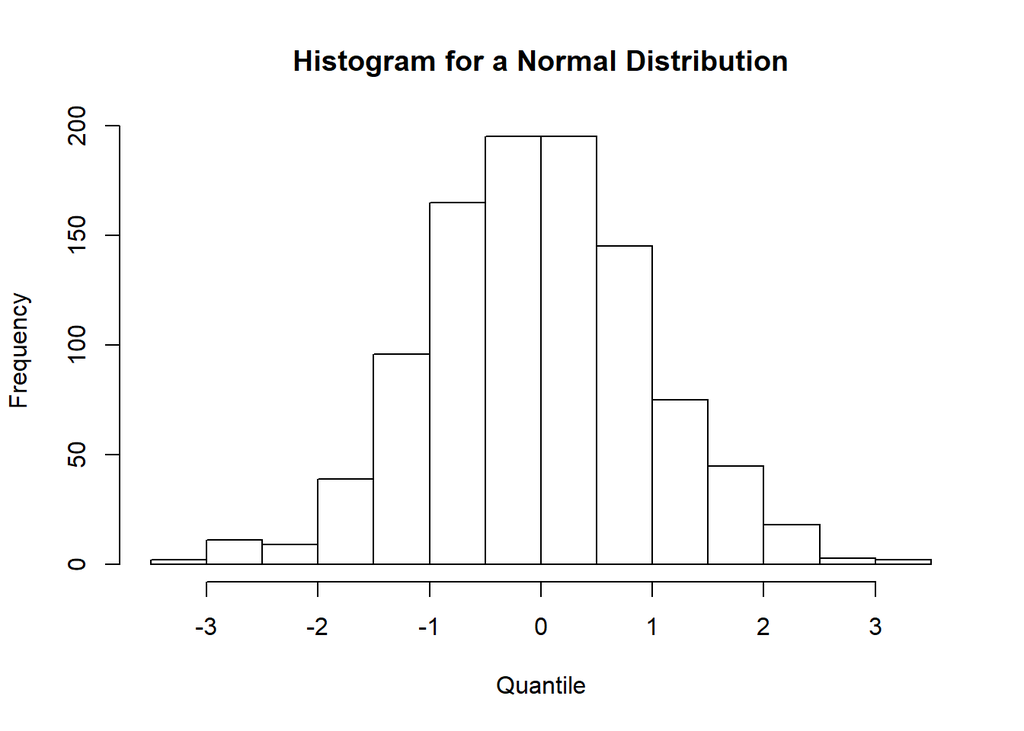

```r
hist(d1, main = "Histogram for a Normal Distribution", xlab = "Quantile")
```

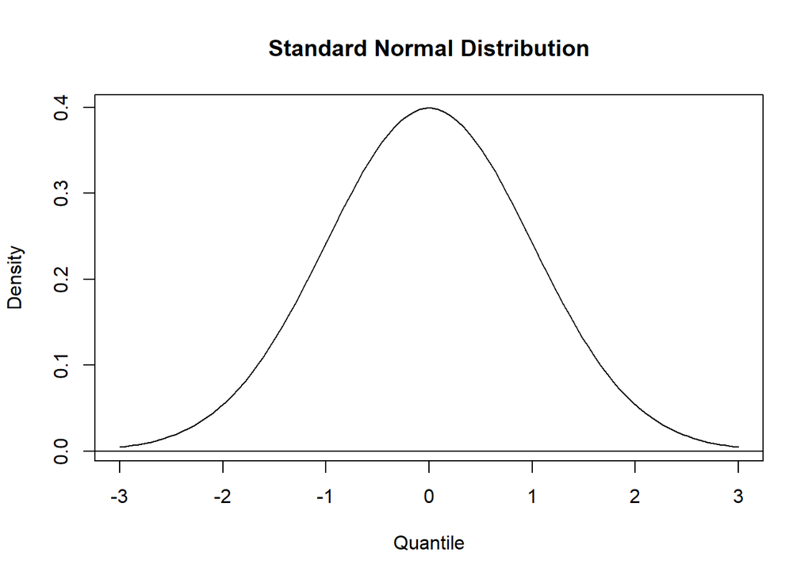

```r
# dXXX()
# Let's try to graph the pdf
x <- seq(from=-3, to=+3, length.out=100) # create an index variable with the data you want, this will be your X axis
y <- dnorm(x) # density (height) of the distribution at that point

# Run all the following commands at the same time
plot(x, y, main="Standard Normal Distribution", type='l',
ylab="Density", xlab="Quantile")
abline(h=0)
```

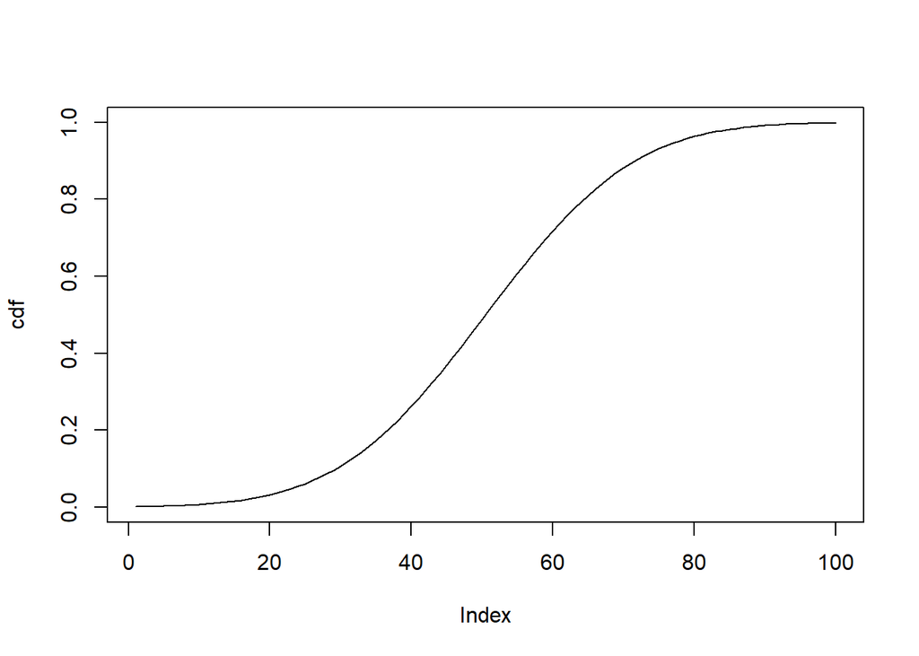

```r
# pXXX()
# let's build a cdf
cdf <- pnorm(x, mean = 0, sd = 1)
plot(cdf, type = 'l')
```

```r
# We can use the pdf to evaluate the percentage of observations to the left or to the right of a given point
pnorm(0.5, mean=0, sd=1)
```

```
## [1] 0.6914625
```

```r
1-pnorm(0.5, mean=0, sd=1)
```

```
## [1] 0.3085375
```

```r
# qxxx()
# it is the inverse of pXXX() if we give the percentage we know the value of the quantile
qnorm(0.69, mean=0, sd=1)
```

```
## [1] 0.4958503
```

### Apply and split

R also has some functions that allows us to split dataframes and to apply the same function to all elements in a determined data structure. The main difference between **lapply** and **sapply** is that the former returns the results in a list while sapply returns the results in a vector if possible. I’m following here chapter 6 on the *R Cookbook* by Teetor.

```r
library(MASS) # load the MASS package so we can use the Cars93 dataset. This dataset contains car sales in the USA in 1993
head(Cars93)
```

```
##   Manufacturer   Model    Type Min.Price Price Max.Price MPG.city MPG.highway
## 1        Acura Integra   Small      12.9  15.9      18.8       25          31
## 2        Acura  Legend Midsize      29.2  33.9      38.7       18          25
## 3         Audi      90 Compact      25.9  29.1      32.3       20          26
## 4         Audi     100 Midsize      30.8  37.7      44.6       19          26
## 5          BMW    535i Midsize      23.7  30.0      36.2       22          30
## 6        Buick Century Midsize      14.2  15.7      17.3       22          31
##              AirBags DriveTrain Cylinders EngineSize Horsepower  RPM
## 1               None      Front         4        1.8        140 6300
## 2 Driver & Passenger      Front         6        3.2        200 5500
## 3        Driver only      Front         6        2.8        172 5500
## 4 Driver & Passenger      Front         6        2.8        172 5500
## 5        Driver only       Rear         4        3.5        208 5700
## 6        Driver only      Front         4        2.2        110 5200
##   Rev.per.mile Man.trans.avail Fuel.tank.capacity Passengers Length Wheelbase
## 1         2890             Yes               13.2          5    177       102
## 2         2335             Yes               18.0          5    195       115
## 3         2280             Yes               16.9          5    180       102
## 4         2535             Yes               21.1          6    193       106
## 5         2545             Yes               21.1          4    186       109
## 6         2565              No               16.4          6    189       105
##   Width Turn.circle Rear.seat.room Luggage.room Weight  Origin          Make
## 1    68          37           26.5           11   2705 non-USA Acura Integra
## 2    71          38           30.0           15   3560 non-USA  Acura Legend
## 3    67          37           28.0           14   3375 non-USA       Audi 90
## 4    70          37           31.0           17   3405 non-USA      Audi 100
## 5    69          39           27.0           13   3640 non-USA      BMW 535i
## 6    69          41           28.0           16   2880     USA Buick Century
```

```r
origin <- split(Cars93$Min.Price, Cars93$Origin) # split the dataset by country of origin and keep the minimum price information
origin
```

```
## $USA
##  [1] 14.2 19.9 22.6 26.3 33.0 37.5  8.5 11.4 13.4 13.4 14.7 14.7 18.0 34.6 18.4
## [16] 14.5 29.5  7.9  8.4 11.9 13.6 14.8 18.5  7.9 17.5  6.9  8.4 10.4 10.8 12.8
## [31] 14.5 15.6 20.1 33.3 34.4 13.3 14.9 13.0 14.2 19.5 19.5 11.4  8.2  9.4 14.0
## [46] 15.4 19.4  9.2
##
## $`non-USA`
##  [1] 12.9 29.2 25.9 30.8 23.7  6.7 11.5 17.0  8.4 13.8  6.8  9.0  9.1 12.4 45.4
## [16] 27.5 34.7  7.4 10.9 14.3 16.6 32.5 29.0 43.8  7.7 22.4  8.7 13.0 16.7 21.0
## [31] 20.3  7.3 10.5 16.3  7.3  7.8 14.2 15.2 18.9  8.7 16.6 17.6 22.9 21.8 24.8
```

```r
# Let's calculate some of the summary statistics for each group (Prices are in $1000)
mean(origin[[1]])
```

```
## [1] 16.53542
```

```r
mean(origin[[2]])
```

```
## [1] 17.75556
```

```r
# Let's try to calculate now the length of each group. The basic structure is lapply(list, function)
lapply(origin, length) # returns a list
```

```
## $USA
## [1] 48
##
## $`non-USA`
## [1] 45
```

```r
sapply(origin, length) # returns a vector, usually working with vectors is sometiems easier.
```

```
##     USA non-USA
##      48      45
```

```r
# Let's calculate the means and medians of both groups
sapply(origin, mean)
```

```
##      USA  non-USA
## 16.53542 17.75556
```

```r
sapply(origin, range) # results in a matrix
```

```
##       USA non-USA
## [1,]  6.9     6.7
## [2,] 37.5    45.4
```

```r
# We can also use apply to matrices, but we need to be careful if we want to calculate the function on each row or on each column. First, let's create a matrix of values for student's scores in different undergrad level courses.
set.seed(1234)
M2 <- matrix(runif(20, min = 3.3, max = 4), nrow = 5, ncol=4)
colnames(M2) <- c("PS1", "Ps2", "Ps3", "PS4")
rownames(M2) <- c("Student 1", "Student 2", "Student 3", "Student 4", "Student 5")
M2
```

```
##                PS1      Ps2      Ps3      PS4
## Student 1 3.379592 3.748217 3.785514 3.886107
## Student 2 3.735610 3.306647 3.681482 3.500356
## Student 3 3.726492 3.462785 3.497914 3.486775
## Student 4 3.736366 3.766259 3.946403 3.430706
## Student 5 3.902641 3.659976 3.504621 3.462558
```

```r
#  apply(array, 1/2, function) if you want to calculate the rows you use 1 and if you want columns you use 2
apply(M2, 1, mean)
```

```
## Student 1 Student 2 Student 3 Student 4 Student 5
##  3.699858  3.556024  3.543491  3.719933  3.632449
```

```r
apply(M2, 2, mean)
```

```
##      PS1      Ps2      Ps3      PS4
## 3.696140 3.588777 3.683187 3.553300
```

### Others and additional resrouces

1. We would deal with results from linear and generalized linear models later. It would be useful to know the structure function [str()] that shows you the internal structure of a given object. This way, if you need to call an element from the stored information you would know how to do it,

```r
df <- cars
lm1 <- lm(dist~speed, data=cars)
str(lm1)
```

```
## List of 12
##  $ coefficients : Named num [1:2] -17.58 3.93
##   ..- attr(*, "names")= chr [1:2] "(Intercept)" "speed"
##  $ residuals    : Named num [1:50] 3.85 11.85 -5.95 12.05 2.12 ...
##   ..- attr(*, "names")= chr [1:50] "1" "2" "3" "4" ...
##  $ effects      : Named num [1:50] -303.914 145.552 -8.115 9.885 0.194 ...
##   ..- attr(*, "names")= chr [1:50] "(Intercept)" "speed" "" "" ...
##  $ rank         : int 2
##  $ fitted.values: Named num [1:50] -1.85 -1.85 9.95 9.95 13.88 ...
##   ..- attr(*, "names")= chr [1:50] "1" "2" "3" "4" ...
##  $ assign       : int [1:2] 0 1
##  $ qr           :List of 5
##   ..$ qr   : num [1:50, 1:2] -7.071 0.141 0.141 0.141 0.141 ...
##   .. ..- attr(*, "dimnames")=List of 2
##   .. .. ..$ : chr [1:50] "1" "2" "3" "4" ...
##   .. .. ..$ : chr [1:2] "(Intercept)" "speed"
##   .. ..- attr(*, "assign")= int [1:2] 0 1
##   ..$ qraux: num [1:2] 1.14 1.27
##   ..$ pivot: int [1:2] 1 2
##   ..$ tol  : num 1e-07
##   ..$ rank : int 2
##   ..- attr(*, "class")= chr "qr"
##  $ df.residual  : int 48
##  $ xlevels      : Named list()
##  $ call         : language lm(formula = dist ~ speed, data = cars)
##  $ terms        :Classes 'terms', 'formula'  language dist ~ speed
##   .. ..- attr(*, "variables")= language list(dist, speed)
##   .. ..- attr(*, "factors")= int [1:2, 1] 0 1
##   .. .. ..- attr(*, "dimnames")=List of 2
##   .. .. .. ..$ : chr [1:2] "dist" "speed"
##   .. .. .. ..$ : chr "speed"
##   .. ..- attr(*, "term.labels")= chr "speed"
##   .. ..- attr(*, "order")= int 1
##   .. ..- attr(*, "intercept")= int 1
##   .. ..- attr(*, "response")= int 1
##   .. ..- attr(*, ".Environment")=<environment: R_GlobalEnv>
##   .. ..- attr(*, "predvars")= language list(dist, speed)
##   .. ..- attr(*, "dataClasses")= Named chr [1:2] "numeric" "numeric"
##   .. .. ..- attr(*, "names")= chr [1:2] "dist" "speed"
##  $ model        :'data.frame':   50 obs. of  2 variables:
##   ..$ dist : num [1:50] 2 10 4 22 16 10 18 26 34 17 ...
##   ..$ speed: num [1:50] 4 4 7 7 8 9 10 10 10 11 ...
##   ..- attr(*, "terms")=Classes 'terms', 'formula'  language dist ~ speed
##   .. .. ..- attr(*, "variables")= language list(dist, speed)
##   .. .. ..- attr(*, "factors")= int [1:2, 1] 0 1
##   .. .. .. ..- attr(*, "dimnames")=List of 2
##   .. .. .. .. ..$ : chr [1:2] "dist" "speed"
##   .. .. .. .. ..$ : chr "speed"
##   .. .. ..- attr(*, "term.labels")= chr "speed"
##   .. .. ..- attr(*, "order")= int 1
##   .. .. ..- attr(*, "intercept")= int 1
##   .. .. ..- attr(*, "response")= int 1
##   .. .. ..- attr(*, ".Environment")=<environment: R_GlobalEnv>
##   .. .. ..- attr(*, "predvars")= language list(dist, speed)
##   .. .. ..- attr(*, "dataClasses")= Named chr [1:2] "numeric" "numeric"
##   .. .. .. ..- attr(*, "names")= chr [1:2] "dist" "speed"
##  - attr(*, "class")= chr "lm"
```

```r
# It makes calling information from an objetc a bit easier
lm1$coefficients[2] # Coefficient for speed
```

```
##    speed
## 3.932409
```

```r
lm1$fitted.values[1] # fitted value for observation 1
```

```
##        1
## -1.84946
```

2. In case you want some R resources, I recommend the following:
   - A basic R guide (https://cran.r-project.org/doc/manuals/R-intro.pdf)
   - How to deal with missing data (https://uc-r.github.io/missing_values)
   - R markdown basics (https://rmarkdown.rstudio.com/authoring_basics.html)
   - Some R style coding guide (https://google.github.io/styleguide/Rguide.xml)